# Assignment 9: Hypothesis Testing and Power and Sample size Determination

Sean Schilk

4/7/2026

## **Simple versus Composite Hypothesis*

**Simple Hypothesis**

- **Simple Hypothesis Test** is a hypothesis that completely specifies the population distribution. Mathematically, simple hypothesis fixes all parameters to specific values. For example, The simple hypotheses are: $H_0: \mu = 5$ (if $\alpha$ is known), $H_0: \mu = 100, \sigma^2 = 25$, and $H_1: p = 0.7$ for a Bernoulli distribution.
- **Example Scenario** Test if a coin is fair:

$$\begin{aligned}
H_0&: p = 0.5 \quad \text{(completely specified)} \\
H_1&: p = 0.6 \quad \text{(also completely specified)}
\end{aligned}$$

Both are **simple** hypotheses.

**Composite Hypothesis**

- **Composite Hypothesis** is a hypothesis that does not completely specify the distribution. Mathematically, it allows a range of values for at least one parameter. For example, in one-sided: $\mu >5$; in two-sided: $\mu \le 5$.
- **Example Scenarios**

$$\begin{aligned}
&H_0: \mu = 5 && \text{(simple)} \\
&H_1: \mu > 5 && \text{(composite)}
\end{aligned}$$
$$\begin{aligned}
&H_0: \mu \leq 5 && \text{(composite)} \\
&H_1: \mu > 5 && \text{(composite)}
\end{aligned}$$
$$\begin{aligned}
&H_0: \text{data follows } N(\mu, 1), \mu = 0 &&
\text{(simple)} \\
&H_1: \text{data follows Poisson}(\lambda) &&
\text{(composite – different family)}
\end{aligned}$$

**This assignment focuses on performing performing a test of mean ($\mu$) a normal population and calculating the power and sample size based on various assumptions**

## **Question: New Cholesterol Medication**

A pharmaceutical company develops **“CholestFix”** to reduce Low-Density Lipoprotein (LDL, *fat carrier that’s low in density*) cholesterol. The **current standard drug** lowers LDL by an average of 25 mg/dL with a standard deviation of 15 mg/dL. A clinical trial with 5 participants were recruited in the study for three months. At the end of the study, the mean reduction is 29 mg/dL. Assume that the variance of LDL reduction of new drug is the same as that of the standard drugs.

Based on the results in the clinical trial, researchers in the company believe **CholestFix** is more effective.

a). Perform a formal hypothesis test of the researchers’ belief regarding LDL reduction, using a significance level of $\alpha = 0.05$.

**1. Gather Available Information for Hypothesis Testing** We want to know the mean LDL reduction using **“CholestFix”**. We are given that a **current standard drug** has an average of 25 mg/dL, with std dev of 15 mg/dL. Our sample data includes a sample size of 5 participants, with sample mean of 29 mg/dL. We want to know if **“CholestFix”** is more effective than our standard drug, meaning this is a right tailed test, with $\mu$ > 25. We will use an alpha of .05.

**2. State the Hypotheses**
$$H_0: \mu = 25$$
$$H_1: \mu > 25$$

**Select An Appropriate Tests Based on Given Information and Evaluate the Test Statistic** We will be using a one-sample z-test here, as we have sample mean, $\mu_0$, std dev, and sample size.

```r
x_bar = 29
mu_0 = 25
std_dev = 15
sample_size = 5

z = (x_bar - mu_0) / (std_dev/sqrt(sample_size))
z
```

```
[1] 0.5962848
```

**Determine the Critical Value(s) and/or P-value**

```r
p_value <- 1 - pnorm(z)
p_value
```

```
[1] 0.2754925
```

**Make a Decision** As we got a pvalue greater than our alpha, .28 > .05, we fail to reject the null hypothesis.

**State the Conclusion in Context** There is insufficient statistical evidence at the .05 level to conclude that **“CholestFix”** lowers LDL more than the current standard drug average of 25 mg/dL.

b). Given $n = 50, \sigma = 15, \alpha = 0.05$, and an effect size we wish to detect $\delta = 4$ mg/dL (corresponding to a reduction from 29 mg/dL to 25 mg/dL). What is the probability that we’d detect a true improvement?

```r
power_calc <- power.t.test(n = 50,
                          delta = 4,
                          sd = 15,
                          sig.level = 0.05,
                          type = "one.sample",
                          alternative = "one.sided")
print(power_calc$power)
```

```
[1] 0.5849737
```

c). Determine the minimum sample size required to detect an effect size of 4 mg/dL with a power of $1 - \beta = 0.8$ and a significance level of $\alpha = 0.05$. Assume the standard deviation of LDL reduction is 15 mg/dL.

```r
# Sample size calculation
sample_size <- power.t.test(power = 0.80,
                            delta = 4,
                           sd = 15,
                           sig.level = 0.05,
                           type = "one.sample",
                           alternative = "one.sided")
cat("\nRequired sample size for 80% power:", ceiling(sample_size$n))
```

```
Required sample size for 80% power: 89
```

Minimum sample size for 80% power is 89. We found that if we increased the sample size from 5 to 89, we could get a power of .8. This makes sense that increasing our sample size would allow us a better chance to capture the true effects of **“CholestFix”** on LDL levels in the body.

d). **Power curve**: To assess the impact of sample size on power, we can create a power function in terms of the sample size $n$ and use the remaining information from part (b). Plot the power curve by selecting a sequence of sample sizes.

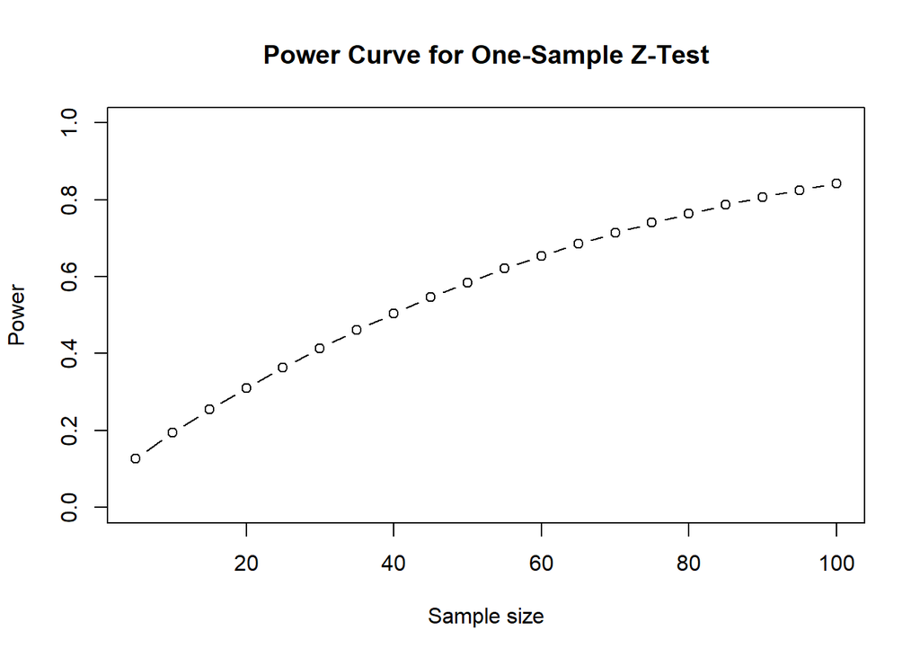

```r
power_function <- function(n) {
  power.t.test(n = n,
               delta = 4,
               sd = 15,
               sig.level = 0.05,
               type = "one.sample",
               alternative = "one.sided")$power
}

n <- seq(5, 100, by = 5)
power <- sapply(n, power_function)


plot(n, power, type = "b",
     xlab = "Sample size",
     ylab = "Power",
     main = "Power Curve for One-Sample Z-Test",
     ylim = c(0, 1))
```

As we found from the earlier question c), increasing the sample size increases the power. This again makes sense as increasing sample size allows studies to detect meaningful effects without wasting resources. We want to know how many people we need to prove the real effects of **“CholestFix”**, for example.

**Note**: For each of the questions above, write a short summary of what you observed, justify why your analysis is valid, and interpret the results.